# Mus chr17 inversions

```r
knitr::opts_chunk$set(echo = TRUE, warning = FALSE, message = FALSE)

#library(ggplot2)
library(tidyverse)
library(cowplot)
library(egg)
library(kableExtra)
library(zoo)
library(ggbeeswarm)
library(ggsignif)
library(here)
library("ggtree")
library(eulerr)
library(car)
library(FSA)
library(ggpubr)
library(reshape2)
library(fuzzyjoin)
source(here("docs", "scripts", "lib", "design.r"))

total_spec = 6

window_size = 10
# Window size in kb

max_tree_rank = 3
```

# 1 Introduction

A closer look at some of the inversions:

```r
calcDivStats <- function(d_file, pair_label){

  return(read_csv(
      d_file, col_names=c("window", "pair.aln.len", "pair.diffs", "out.aln.len", "pair.out.diffs", "x.out", "y.out")) %>%
        mutate(window = gsub(".filter.fa", "", window)) %>%
        # Parse the window name

        mutate(dxy.pair = pair.diffs / pair.aln.len) %>%
        # Calculate dxy for the pair of species using the pair alignment length

        mutate(dxy.jc.pair = -(3/4) * (log(1 - ((4/3) * dxy.pair)))) %>%
        mutate(dxy.jc.pair = ifelse(dxy.jc.pair == Inf, NA, dxy.jc.pair)) %>%
        # Calculate dxy with the JC correction for the pair of species using the pair alignment length

        mutate(dxy.pair.out = pair.out.diffs / out.aln.len) %>%
        # Calculate dxy for the pair of species using the alignment length with the outgroup

        mutate(dxy.jc.pair.out = -(3/4) * (log(1 - ((4/3) * dxy.pair.out)))) %>%
        mutate(dxy.jc.pair.out = ifelse(dxy.jc.pair.out == Inf, NA, dxy.jc.pair.out)) %>%
        # Calculate dxy with the JC correction for the pair of species using the alignment length with the outgroup

        mutate(dxout = x.out / out.aln.len) %>%
        # Calculate dxy for x and the outgroup

        mutate(dxout.jc = -(3/4) * (log(1 - ((4/3) * dxout)))) %>%
        mutate(dxout.jc = ifelse(dxout.jc == Inf, NA, dxout.jc)) %>%
        # Calculate dxy with the JC correction for x and the outgroup

        mutate(dyout = y.out / out.aln.len) %>%
        # Calculate dxy for y and the outgroup

        mutate(dyout.jc = -(3/4) * (log(1 - ((4/3) * dyout)))) %>%
        mutate(dyout.jc = ifelse(dyout.jc == Inf, NA, dyout.jc)) %>%
        # Calculate dxy with the JC correction for y and the outgroup

        mutate(dxy.out = (dxout + dyout) / 2) %>%
        mutate(dxy.jc.out = (dxout.jc + dyout.jc) / 2) %>%
        # Average d for x and y compared to the outgroup

        mutate(rnd = dxy.pair.out / dxy.out) %>%
        mutate(rnd.jc = dxy.jc.pair.out / dxy.jc.out) %>%
        # Calculate RND from the dxy using the alignment with the outgroup

        mutate(label = pair_label) %>%
        # Add the species label

        filter(pair.aln.len >= 5000) %>%

        filter(dxy.pair <= 0.10)

        # mutate(a.pair = pair.diffs / aln.len) %>%
        # mutate(d.pair.jc = -(3/4) * (log(1 - ((4/3) * a.pair)))) %>%
        # mutate(d.pair.jc = ifelse(d.pair.jc == Inf, NA, d.pair.jc)) %>%
        # mutate(a.out.x = x.out / aln.len) %>%
        # mutate(d.out.x.jc = -(3/4) * (log(1 - ((4/3) * a.out.x)))) %>%
        # mutate(a.out.y = y.out / aln.len) %>%
        # mutate(d.out.y.jc = -(3/4) * (log(1 - ((4/3) * a.out.y)))) %>%
        # mutate(a.out = (a.out.x + a.out.y) / 2) %>%
        # mutate(d.out.jc = (d.out.x.jc + d.out.y.jc) / 2) %>%
        # #mutate(d.out.jc = ifelse(is.nan(d.out.jc), NA, d.out.jc)) %>%
        # mutate(rnd = a.pair / a.out) %>%
        # mutate(rnd.log = log10(rnd)) %>%
        # mutate(rnd.jc = d.pair.jc / d.out.jc) %>%
        # mutate(rnd.jc.log = log10(rnd.jc)) %>%
        # #mutate(rnd.jc.log = ifelse(is.nan(rnd.jc.log), NA, rnd.jc.log)) %>%
        # mutate(label = pair_label)
  )

}

getBreakpointWins <- function(df, inv_df, threshold=100000){
  near_start_windows = df %>% distance_inner_join(inv_df, by=c("start"="start"), max_dist=threshold)
  # Use the distance_inner_join function to find windows that are within the threshold of the start values

  near_end_windows = df %>% distance_inner_join(inv_df, by=c("end"="end"), max_dist=threshold)
  # Use the distance_inner_join function to find windows that are within the threshold of the end values

  near_windows = bind_rows(near_start_windows, near_end_windows)
  # Combine the results

  df$near.breakpoint <- df$start %in% near_windows$start.x & df$end %in% near_windows$end.x
  # Add a new column near.breakpoint that is TRUE if the window is near the positions in the second data frame and FALSE otherwise

  return(df)
}
```

```r
min_aln_len = 9000

##########

aln_stats_file = here("data", paste0("mm10-", window_size, "kb-window-stats-no-pahari.tsv"))
aln_stats = read.csv(aln_stats_file, header=T, comment.char="#", sep="\t")
aln_stats$window <- gsub('.noanc', '', aln_stats$window)
# Window alignment stats

##########

infile = here("data", paste0("mm10-", window_size, "kb-topo-counts-no-pahari.csv"))
all_windows = read.csv(infile, header=T, comment.char="#")
all_windows = all_windows[order(-all_windows$end), ]
all_windows = all_windows %>%
  mutate(aln.len.filter = aln_stats$aln.len.filter[match(window, aln_stats$window)])
# Window trees file

##########

inversions_file = here("data", "inversions.bed")
inversions = read_tsv(inversions_file, col_names=c("chr", "start", "end", "id"))
inversions$length = inversions$end - inversions$start
inversions$num.windows = inversions$length / (window_size * 1000)

inversions %>%
  kable() %>%
  kable_styling(bootstrap_options=c("striped", "condended", "responsive"), full_width=F, position="center", fixed_thead=T)
```

| chr | start | end | id | length | num.windows |
| --- | --- | --- | --- | --- | --- |
| chr17 | 5747330 | 6957919 | inv01 | 1210589 | 121.0589 |
| chr17 | 7435307 | 13016510 | inv02 | 5581203 | 558.1203 |
| chr17 | 14068228 | 18051507 | inv03 | 3983279 | 398.3279 |
| chr17 | 19400999 | 40049964 | inv04 | 20648965 | 2064.8965 |

```r
# Inversions

##########

dists_file = here("data", "coord-query-no-pahari", "inv-bps-5-Mb.bed.chr17.dists.all")
dists = read_csv(dists_file)
dists$label = NA
dists = dists %>%
  mutate(aln.len.filter = aln_stats$aln.len.filter[match(window, aln_stats$window)])
if(!is.na(dists$filt)){
  dists$label = ifelse(dists$rf.st == 0, "Same", "Diff")
}
# Tree dists

##########

intersects_file = here("data", "mm10-10kb-windows-inversions.intersect")
intersects = read_tsv(intersects_file, col_names=c("chr", "start", "end", "window", "inv.chr", "inv.start", "inv.end", "inv.overlap", "inv.overlap.bp"))
intersects = intersects %>% filter(inv.overlap.bp > 1) %>% select(window, inv.overlap, inv.overlap.bp)
# Read the windows with inversion intersects labeled

##########

all_windows = left_join(all_windows, intersects, by="window")
all_windows = getBreakpointWins(all_windows, inversions)

all_windows_f = all_windows %>% filter(filter=="PASS") %>%
  filter(aln.len.filter >= min_aln_len)
#all_windows_f = getBreakpointWins(all_windows_f, inversions)

dists = left_join(dists, intersects, by="window")
dists = dists %>% filter(filt=="PASS") %>%
  filter(aln.len.filter >= min_aln_len)

dists = getBreakpointWins(dists, inversions)
# Add the inversion intersects to the windows and dists dfs

##########

mm_t_sites_file = here("data", "rnd", "sister", "mm10-mus-t.csv")
mm_t_sites = calcDivStats(mm_t_sites_file, "mm10-mus-t")
mm_t_sites = right_join(mm_t_sites, all_windows, by="window") %>% mutate(label="mm10-mus-t")
mm_t_quant = quantile(mm_t_sites$rnd.jc, probs=c(0.05), na.rm=T)

spi_spr_sites_file = here("data", "rnd", "sister", "spicilegus-spretus.csv")
spi_spr_sites = calcDivStats(spi_spr_sites_file, "spicilegus-spretus")
spi_spr_sites = right_join(spi_spr_sites, all_windows, by="window") %>% mutate(label="spicilegus-spretus")
spi_spr_quant = quantile(spi_spr_sites$rnd.jc, probs=c(0.05), na.rm=T)

mm_spi_sites_file = here("data", "rnd", "non-sister", "mm10-spicilegus.csv")
mm_spi_sites = calcDivStats(mm_spi_sites_file, "mm10-spicilegus")
mm_spi_sites = right_join(mm_spi_sites, all_windows, by="window") %>% mutate(label="mm10-spicilegus")
mm_spi_quant = quantile(mm_spi_sites$rnd.jc, probs=c(0.05), na.rm=T)

t_spi_sites_file = here("data", "rnd", "non-sister", "mus-t-spicilegus.csv")
t_spi_sites = calcDivStats(t_spi_sites_file, "mus-t-spicilegus")
t_spi_sites = right_join(t_spi_sites, all_windows, by="window") %>% mutate(label="mus-t-spicilegus")
t_spi_quant = quantile(t_spi_sites$rnd.jc, probs=c(0.05), na.rm=T)

mm_spr_sites_file = here("data", "rnd", "non-sister", "mm10-spretus.csv")
mm_spr_sites = calcDivStats(mm_spr_sites_file, "mm10-spretus")
mm_spr_sites = right_join(mm_spr_sites, all_windows, by="window") %>% mutate(label="mm10-spretus")
mm_spr_quant = quantile(mm_spr_sites$rnd.jc, probs=c(0.05), na.rm=T)

t_spr_sites_file = here("data", "rnd", "non-sister", "mus-t-spretus.csv")
t_spr_sites = calcDivStats(t_spr_sites_file, "mus-t-spretus")
t_spr_sites = right_join(t_spr_sites, all_windows, by="window") %>% mutate(label="mus-t-spretus")
t_spr_quant = quantile(t_spr_sites$rnd.jc, probs=c(0.05), na.rm=T)

sites_by_windows = bind_rows(mm_t_sites, mm_spi_sites, mm_spr_sites, t_spi_sites, t_spr_sites, spi_spr_sites)
sites_by_windows = sites_by_windows %>%
  arrange(start) %>%
  group_by(label) %>%
  filter(filter=="PASS") %>%
  filter(aln.len.filter >= min_aln_len)

sites_by_windows = getBreakpointWins(sites_by_windows, inversions)
all_quant = quantile(sites_by_windows$rnd.jc, probs=c(0.05), na.rm=T)

#sites_by_windows = right_join(all_sites, all_windows, by="window")

##########

# recomb_file = here("data", "Revised_HSmap_SNPs-mm10-1mb-rates.csv")
# recomb = read_csv(recomb_file) %>%
#   filter(chr == "17") %>%
#   group_by(window) %>%
#   summarize(rate=slope, start=win.start)

# all_windows_f = all_windows_f %>% filter(near.breakpoint == FALSE)
# dists = dists %>% filter(near.breakpoint == FALSE)
# sites_by_windows = sites_by_windows %>% filter(near.breakpoint == FALSE)
```

```r
all_topos = sort(unique(all_windows$topo.num.overall))

topo_counts = unique(subset(all_windows_f, select=c(topo.num.overall, topo.count.overall, topo.rank.overall, topo.color)))

filtered_topos = all_topos[!all_topos %in% topo_counts$topo.num.overall]
# Identify the ids in all_topos that are not in topo_counts

missing_ranks = all_windows$topo.rank.overall[match(filtered_topos, all_windows$topo.num.overall)]
# Get the corresponding values in all_windows$topo.rank.overall

filtered_topos_df = data.frame(
  topo.num.overall = filtered_topos,
  topo.count.overall = 0,
  topo.rank.overall = missing_ranks,
  topo.color = "#999999"
)
# Create a new data frame for these ids

# Add the new rows to topo_counts
topo_counts = bind_rows(topo_counts, filtered_topos_df)


num_topos = nrow(topo_counts)
# Get the topology counts

#print(paste0("In total ", num_topos, " different topologies were recovered"))
# Display some info

col_rank = 1
for(i in unique(topo_counts$topo.num.overall)){
  row = subset(topo_counts, topo.num.overall==i)

  cur_col = row$topo.color

  if(cur_col != "#999999"){
    new_label = paste("Top ", col_rank, sep="")
    col_rank = col_rank + 1
  }else{
    new_label = "Other"
  }

  topo_counts$col.cat[topo_counts$topo.num.overall==i] = new_label

  if(row$topo.rank.overall > max_tree_rank){
    topo_counts$topo.color[topo_counts$topo.num.overall==i] = "#333333"
  }

}
# Add label and color columns to the topo counts

topo_counts = topo_counts[order(topo_counts$topo.rank.overall),]

topo_counts$outline = "transparent"
# Add an outline column -- black outline is chrome topo

topo_counts$topo.prop = round(topo_counts$topo.count / sum(topo_counts$topo.count), 2)
# Percentage for each topology.
```

```r
genChromoPlot <- function(chrome_str, label, features=FALSE, cur_feature=FALSE, num_flank_windows=0, multi_row=TRUE){
# chrome_str:       the chromosome to be subset
# label:            a title, not currently used
# features:         a set of coordinates to be marked on the chromoplot
# cur_feature:      if a single feature is provided here, the chromoplot will be subset to show just that region
# num_flank_window: the number of windows surrounding a feature to subset; to be used with cur_feature, otherwise ignored
# multi_row:        whether or not to display the top three topologies in separate rows on the chromoplot

  if(!cur_feature==FALSE){
    flank = num_flank_windows * window_size * 1000
    chrdata = subset(all_windows_f, chr==chrome_str & start > cur_feature$start - flank & end < cur_feature$end + flank)
  }else{
    chrdata = subset(all_windows_f, chr==chrome_str)
  }
  # Subset the data by chromosome and feature (if provided)

  ##########

  chr_len = chrdata[chrdata$chr==chrome_str, ]$chr.len[1]
  # Get the chromosome length

  chrdata$col.cat = NA
  chrdata$ystart = NA
  chrdata$yend = NA
  # Initialize some empty columns in the data

  cur_col = "#ffffff"
  topo_counts$topo.color = as.character(topo_counts$topo.color)
  # Other setup

  for(i in 1:nrow(chrdata)) {
    cur_topo_num = chrdata[i,]$topo.num.overall
    # Get the topology number/id of the current window

    if(aln_stats[aln_stats$window == chrdata[i,]$window,]$total.seqs.filter != 5){
      cur_col = "#999999"
      chrdata[i,]$ystart = 0
      chrdata[i,]$yend = 4
    # If this window was filtered out in the alignment steps, set the color to grey and the y coords to span the chromoplot (0 to 4)
    }else if(is.na(cur_topo_num)){
      cur_col = "#999999"
      chrdata[i,]$ystart = 0
      chrdata[i,]$yend = 4
    # If this window was filtered out otherwise, set the color to grey and the y coords to span the chromoplot (0 to 4)
    }else{
      cur_col = topo_counts$topo.color[topo_counts$topo.num.overall==cur_topo_num]
    # If this window was not filtered, set the current color to be the one for the rank by frequency
    }

    chrdata[i,]$col.cat = cur_col
    # Set the color for this window based on above

  }
  ## Categorize the windows and get their colors

  ##########

  if(multi_row){
    chrdata$ystart[chrdata$topo.rank.overall==1] = 4
    chrdata$yend[chrdata$topo.rank.overall==1] = 3

    chrdata$ystart[chrdata$topo.rank.overall==2] = 3
    chrdata$yend[chrdata$topo.rank.overall==2] = 2

    chrdata$ystart[chrdata$topo.rank.overall==3] = 2
    chrdata$yend[chrdata$topo.rank.overall==3] = 1

    chrdata$ystart[chrdata$topo.rank.overall>3] = 1
    chrdata$yend[chrdata$topo.rank.overall>3] = 0
  # If the plot is multi-line, topologies of rank 1, 2, and 3 get their own rows
  }else{
    chrdata$ystart = 1
    chrdata$yend = 0
  # If the plot is not multi-line, all columns go from 0 to 1
  }
  ## Set the y coordinates for the chromoplot

  ##########

  cols_labs = levels(as.factor(chrdata$col.cat))
  names(cols_labs) = levels(as.factor(chrdata$col.cat))
  # Set up the colors

  cur_len = max(chrdata$end) - min(chrdata$start)
  chr_breaks = seq(min(chrdata$start), max(chrdata$end), by=cur_len/5)
  # Set up the x-axis breaks

  chromoplot = ggplot(chrdata, aes(x=start, y=ystart, color=col.cat, fill=col.cat))

  if(!features==FALSE){
    offset = 3
    feature_cols = corecol(numcol=nrow(features), offset=offset)
    chromoplot = chromoplot +
      geom_rect(data=features, inherit.aes=F, aes(ymin=-Inf, ymax=Inf, xmin=start, xmax=end), alpha=0.2, fill=feature_cols)
  }

  chromoplot = chromoplot +
    geom_rect(aes(ymin=ystart, ymax=yend, xmin=start, xmax=end)) +
    scale_color_manual(values=cols_labs) +
    scale_fill_manual(values=cols_labs) +
    scale_x_continuous(limits=c(min(chrdata$start), max(chrdata$end)), breaks=chr_breaks) +
    xlab("Position") +
    bartheme() +
    theme(legend.position="none",
          legend.key.width = unit(0.75,  unit = "cm"),
          legend.spacing.x = unit(0.25, 'cm'),
          legend.title = element_blank(),
          #legend.text=element_text(size=12),
          axis.text=element_text(size=8),
          axis.title=element_text(size=10),
          axis.line.y=element_line(color="white"),
          axis.ticks.y=element_line(color="white"),
          axis.text.y=element_text(color="white"),
          axis.title.y=element_text(angle=0),
          plot.margin = unit(c(0,0,0,0), "cm")
  )

  if(!features==FALSE){
    offset = 3
    for(i in 1:nrow(features)){
      chromoplot = chromoplot +
        geom_vline(xintercept=features[i,]$start, color=corecol(numcol=1, offset=offset), size=1) +
        geom_vline(xintercept=features[i,]$end, color=corecol(numcol=1, offset=offset), size=1)
      offset = offset + 1
    }
  }
  # If a set of features have been provided to be marked, draw vertical lines at their boundaries here

  if(multi_row){
    chromoplot = chromoplot +
      scale_y_continuous(limits=c(0,4), breaks=0.5:3.5, labels=c("0.0", "3", "2", "1")) +
      ylab("Topology")
  }else{
    chromoplot = chromoplot +
      scale_y_continuous(limits=c(0,1), breaks=0.5:1.5, labels=c("0.0", "")) +
      ylab("Topology")
  }
  # Set up the y-axis based on whether the plot is multi-line or not

  return(chromoplot)
  # Return the plot
}
```

```r
genRFPlot <- function(df, yvar, chrome_str, label, ylab, type="point", ymax=FALSE, quantline=FALSE, groups=FALSE, features=FALSE, cur_feature=FALSE, num_flank_windows=0, num_roll_windows=1){
# chrome_str:       the chromosome to be subset
# label:            a title, not currently used
# features:         a set of coordinates to be marked on the chromoplot
# cur_feature:      if a single feature is provided here, the chromoplot will be subset to show just that region
# num_flank_window: the number of windows surrounding a feature to subset; to be used with cur_feature, otherwise ignored

  chrdata = df %>%
    filter(chr == chrome_str)

  if(!cur_feature==FALSE){
    flank = num_flank_windows * window_size * 1000
    chrdata = chrdata %>%
      filter(start > cur_feature$start - flank & end < cur_feature$end + flank)
  }
  # Subset the data by chromosome and feature (if provided)

  chrdata = chrdata %>%
    arrange(start)

  if(!groups==FALSE){
    chrdata = chrdata %>%
      group_by(!!groups)
  }

  if(type=="roll"){
    chrdata = chrdata %>%
    mutate(!!yvar := rollapply(!! rlang::sym(yvar), width=num_roll_windows, FUN=function(x) mean(x, na.rm=TRUE), partial=F, fill=NA, align="left"))
  }

  ##########

  #qts = quantile(chrdata$wrf.st, probs=c(.05,.95), na.rm=T)
  # Calculate some percentiles (not currently used)

  cols = rev(c(corecol(pal="wilke", numcol=4, offset=4)))
  # Set up the colors (not currently used)

  cur_len = max(chrdata$end) - min(chrdata$start)
  chr_breaks = seq(min(chrdata$start), max(chrdata$end), by=cur_len/5)
  # Set up the x-axis breaks

  if(!groups==FALSE){
    wrf_adj = ggplot(chrdata, aes_string(x="start", y=yvar, color=groups)) +
      scale_color_manual(values=corecol(pal="wilke", numcol=length(unique(chrdata[[groups]]))))
  }else{
    wrf_adj = ggplot(chrdata, aes_string(x="start", y=yvar))
  }

  if(!features==FALSE){
    offset = 3
    feature_cols = corecol(numcol=nrow(features), offset=offset)
    wrf_adj = wrf_adj +
      geom_rect(data=features, inherit.aes=F, aes(ymin=0, ymax=Inf, xmin=start, xmax=end), alpha=0.1, fill=feature_cols)
  }

  if(type=="point"){
    wrf_adj = wrf_adj +
      geom_point(size=1, alpha=0.1)
      #geom_smooth(se=F)
  }else if(type == "line"){
    wrf_adj = wrf_adj +
      geom_line()
  }else if(type == "roll"){
    wrf_adj = wrf_adj +
      #geom_line(aes(y=rollapply(chrdata[[yvar]], width=num_roll_windows, FUN=function(x) mean(x, na.rm=TRUE), partial=F, fill=NA, align="left")))
      geom_line()
  }else if(type == "smooth"){
    wrf_adj = wrf_adj +
      geom_smooth(se=F)
  }


  if(!quantline==FALSE){
    wrf_adj = wrf_adj +
      geom_hline(yintercept=quantline, size=0.75, linetype="dashed", color="#f0e442")
  }

  if(!ymax==FALSE){
    if(ymax=="logy"){
      wrf_adj = wrf_adj +
        scale_y_log10()
    }else{
      wrf_adj = wrf_adj +
        scale_y_continuous(limits=c(0, ymax))
    }
  }

  wrf_adj = wrf_adj +
    scale_x_continuous(limits=c(min(chrdata$start), max(chrdata$end)), breaks=chr_breaks) +
    xlab(NULL) +
    ylab(ylab) +
    bartheme() +
    #theme_classic() +
    theme(axis.text=element_text(size=8),
          axis.title=element_text(size=10),
          #axis.line.x=element_blank(),
          axis.ticks.x=element_blank(),
          axis.title.x=element_blank(),
          axis.text.x=element_blank(),
          axis.title.y=element_text(angle=0),
          plot.margin = grid::unit(c(0,0,0,0), "cm"),
          axis.ticks.length.x = unit(2, "pt"),
          legend.position="bottom")
          #plot.background = element_rect(color = "deepskyblue3", linewidth = 3))

  if(!features==FALSE){
    offset = 3
    for(i in 1:nrow(features)){
      wrf_adj = wrf_adj +
        geom_vline(xintercept=features[i,]$start, color=corecol(numcol=1, offset=offset), size=1) +
        geom_vline(xintercept=features[i,]$end, color=corecol(numcol=1, offset=offset), size=1)
      offset = offset + 1
    }
  }
  # If a set of features have been provided to be marked, draw v lines at their boundaries here

  leg = get_legend(wrf_adj)

  wrf_adj = wrf_adj +
    theme(legend.position = "none")

  return(list(wrf_adj, leg))
  # Return the plot
}
```

In the plots below, I show several statistics on 10kb windows along mm10 chromosome 17 and outline the boundaries of the inversions. I show:

1. For two branches, the divergence of each pair of sequences, $d$ (or $d_{XY}$):

$$d_{XY} = \frac{n_d}{n}$$

where $n_d$ is the number of sites where the nucleotides differ between the two sequences and $n$ is the total number of aligned (non-gap) sites between the two sequences.

2. Relative Node Depth ($RND$) for the specified pair of sequences. This statistic uses $d$ between a pair of species, $d_{XY}$, and compares it to the average $d$ from each species to an outgroup, $d_{out}$. $d_{XY}$ is calculated as above, while $d_{XO}$ and $d_{YO}$ are calculated the same way, but between species $X$ and the outgroup, $O$, and species $Y$ and $O$. Then,

$$d_{out} = \frac{d_{XO} +d_{YO}}{2}$$

and

$$RND = \frac{d_{XY}}{d_{out}}$$

LOWER values of $RND$ can be indicative of introgression. See [Rosenzweig et al. 2016](https://hahnlab.sitehost.iu.edu/Publications/Rosenzweig_etal2016.pdf) for more info. Each line represents one comparisong between a pair of species.

3. Weighted Robinson-Foulds (wRF) distance between each window tree and the SPECIES TREE. I gave a brief explanation of wRF [here](https://gwct.github.io/mus-t-haplotype/trees_no_pahari.html#tree-similarity-in-windows-around-inversion-breakpoints). In this case, the REFERENCE TREE is ALWAYS the SPECIES TREE and the QUERY TREE is the tree inferred from that 10kb window. Each dot represents the wRF for one 10kb window.
4. The chromoplot visualizing topological differences in window trees. The colors are the same as [here](https://gwct.github.io/mus-t-haplotype/trees_no_pahari.html#distribution-of-tree-topologies).

For each panel, vertical shaded regions represent the locations of the inversions.

## 1.1 Additional filtering

# 2 Chromosome 17

Rolling mean using a sliding window of 100 10kb windows for $d$ and $RND$ (1Mb with 10kb step).

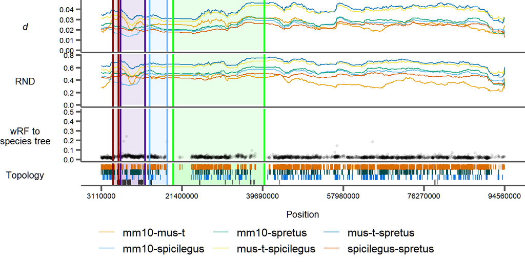

```r
sites_by_windows = sites_by_windows %>%
  mutate(roll.dxy.pair = rollapply(dxy.pair, width=100, FUN=function(x) mean(x, na.rm=TRUE), partial=T, fill=NA, align="left")) %>%
  mutate(roll.rnd = rollapply(rnd, width=100, FUN=function(x) mean(x, na.rm=TRUE), partial=T, fill=NA, align="left"))

#####

cur_chromoplot = genChromoPlot("chr17", "Chromosome 17", features=inversions)

#####

cur_rfplot = genRFPlot(dists, "wrf.st", "chr17", "Chromosome 17", "wRF to\nspecies tree", ymax=0.5, features=inversions)

#####

cur_d_plot = genRFPlot(sites_by_windows, "roll.dxy.pair", "chr17", "Inversion 1", expression(italic("d")), type="line", groups="label", features=inversions)

cur_rnd_plot = genRFPlot(sites_by_windows, "roll.rnd", "chr17", "Inversion 1", "RND", type="line", groups="label", features=inversions)

p_main = plot_grid(cur_d_plot[[1]], cur_rnd_plot[[1]], cur_rfplot[[1]], cur_chromoplot, nrow=4, align="v", rel_heights=c(1,1,1,1,1,2))
#print(p_main)
p = plot_grid(p_main, cur_d_plot[[2]], nrow=2, rel_heights=c(1,0.2))
print(p)
```

# 3 Inversion 1

Rolling mean using a sliding window of 5 10kb windows for $d$ and $RND$ (50kb with 10kb step).

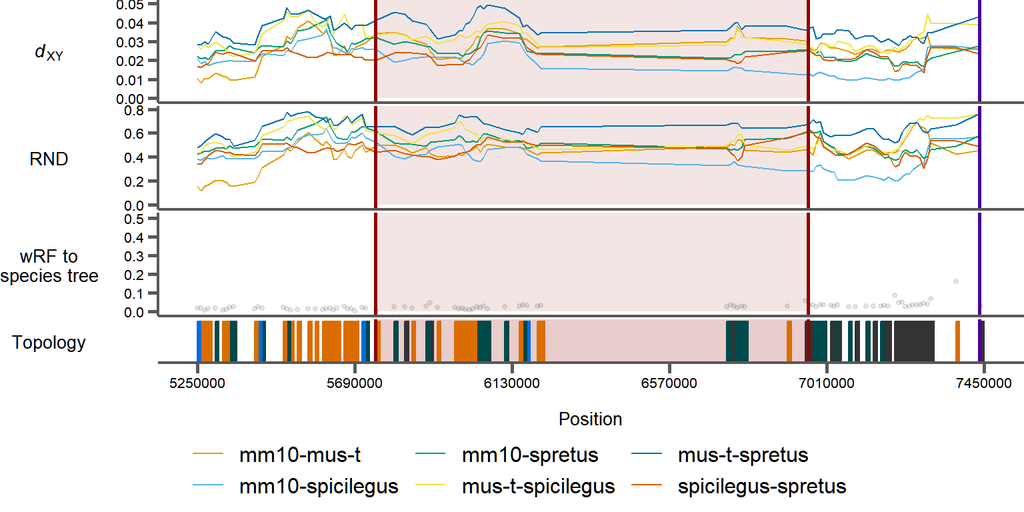

```r
sites_by_windows = sites_by_windows %>%
  mutate(roll.dxy.pair = rollapply(dxy.pair, width=5, FUN=function(x) mean(x, na.rm=TRUE), partial=T, fill=NA, align="left")) %>%
  mutate(roll.rnd = rollapply(rnd, width=5, FUN=function(x) mean(x, na.rm=TRUE), partial=T, fill=NA, align="left"))

#####

cur_chromoplot = genChromoPlot("chr17", "Inversion 1", features=inversions, cur_feature=inversions[1,], num_flank_windows=50, multi_row=F)

#####

cur_rfplot = genRFPlot(dists, "wrf.st", "chr17", "Inversion 1", "wRF to\nspecies tree", ymax=0.5, features=inversions, cur_feature=inversions[1,], num_flank_windows=50)

#####

cur_d_plot = genRFPlot(sites_by_windows, "roll.dxy.pair", "chr17", "Inversion 1", expression(italic("d")[XY]), type="line", groups="label", features=inversions, cur_feature=inversions[1,], num_flank_windows=50)

cur_rnd_plot = genRFPlot(sites_by_windows, "roll.rnd", "chr17", "Inversion 1", "RND", type="line", groups="label", features=inversions, cur_feature=inversions[1,], num_flank_windows=50)

p_main = plot_grid(cur_d_plot[[1]], cur_rnd_plot[[1]], cur_rfplot[[1]], cur_chromoplot, nrow=4, align="v", rel_heights=c(1,1,1,1,1,2))
#print(p_main)
p = plot_grid(p_main, cur_d_plot[[2]], nrow=2, rel_heights=c(1,0.2))
print(p)
```

# 4 Inversion 2

Rolling mean using a sliding window of 10 10kb windows for $d$ and $RND$ (100kb with 10kb step).

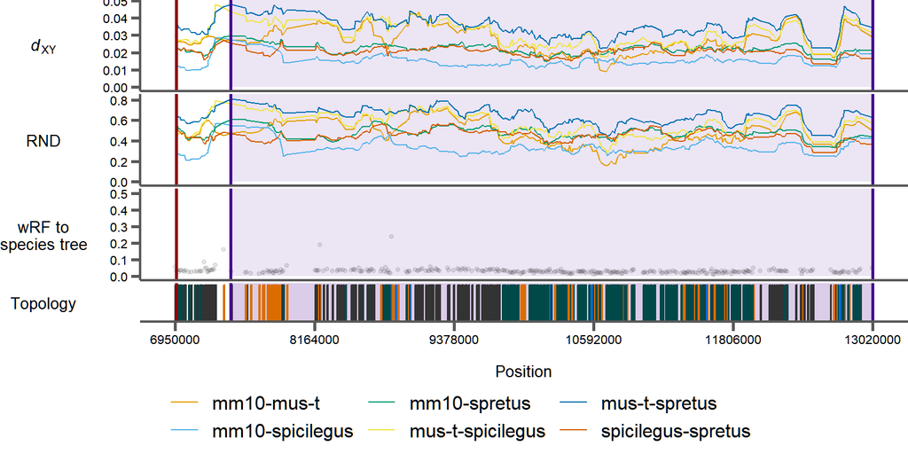

```r
sites_by_windows = sites_by_windows %>%
  mutate(roll.dxy.pair = rollapply(dxy.pair, width=10, FUN=function(x) mean(x, na.rm=TRUE), partial=T, fill=NA, align="left")) %>%
  mutate(roll.rnd = rollapply(rnd, width=10, FUN=function(x) mean(x, na.rm=TRUE), partial=T, fill=NA, align="left"))

#####

cur_chromoplot = genChromoPlot("chr17", "Inversion 2", features=inversions, cur_feature=inversions[2,], num_flank_windows=50, multi_row=F)

#####

cur_rfplot = genRFPlot(dists, "wrf.st", "chr17", "Inversion 2", "wRF to\nspecies tree", ymax=0.5, features=inversions, cur_feature=inversions[2,], num_flank_windows=50)

#####

cur_d_plot = genRFPlot(sites_by_windows, "roll.dxy.pair", "chr17", "Inversion 2", expression(italic("d")[XY]), type="line", groups="label", features=inversions, cur_feature=inversions[2,], num_flank_windows=50)

cur_rnd_plot = genRFPlot(sites_by_windows, "roll.rnd", "chr17", "Inversion 2", "RND", type="line", groups="label", features=inversions, cur_feature=inversions[2,], num_flank_windows=50)

p_main = plot_grid(cur_d_plot[[1]], cur_rnd_plot[[1]], cur_rfplot[[1]], cur_chromoplot, nrow=4, align="v", rel_heights=c(1,1,1,1,1,2))
p = plot_grid(p_main, cur_d_plot[[2]], nrow=2, rel_heights=c(1,0.2))
print(p)
```

# 5 Inversion 3

Rolling mean using a sliding window of 10 10kb windows for $d$ and $RND$ (100kb with 10kb step).

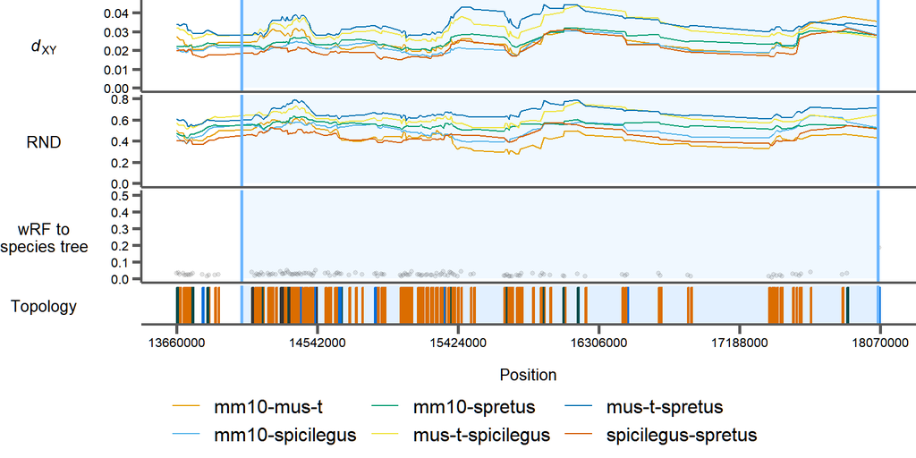

```r
sites_by_windows = sites_by_windows %>%
  mutate(roll.dxy.pair = rollapply(dxy.pair, width=10, FUN=function(x) mean(x, na.rm=TRUE), partial=T, fill=NA, align="left")) %>%
  mutate(roll.rnd = rollapply(rnd, width=10, FUN=function(x) mean(x, na.rm=TRUE), partial=T, fill=NA, align="left"))

#####

cur_chromoplot = genChromoPlot("chr17", "Inversion 3", features=inversions, cur_feature=inversions[3,], num_flank_windows=50, multi_row=F)

#####

cur_rfplot = genRFPlot(dists, "wrf.st", "chr17", "Inversion 3", "wRF to\nspecies tree", ymax=0.5, features=inversions, cur_feature=inversions[3,], num_flank_windows=50)

#####

cur_d_plot = genRFPlot(sites_by_windows, "roll.dxy.pair", "chr17", "Inversion 3", expression(italic("d")[XY]), type="line", groups="label", features=inversions, cur_feature=inversions[3,], num_flank_windows=50)

cur_rnd_plot = genRFPlot(sites_by_windows, "roll.rnd", "chr17", "Inversion 3", "RND", type="line", groups="label", features=inversions, cur_feature=inversions[3,], num_flank_windows=50)

p_main = plot_grid(cur_d_plot[[1]], cur_rnd_plot[[1]], cur_rfplot[[1]], cur_chromoplot, nrow=4, align="v", rel_heights=c(1,1,1,1,1,2))
p = plot_grid(p_main, cur_d_plot[[2]], nrow=2, rel_heights=c(1,0.2))
print(p)
```

# 6 Inversion 4

Rolling mean using a sliding window of 100 10kb windows for $d$ and $RND$ (1Mb with 10kb step).

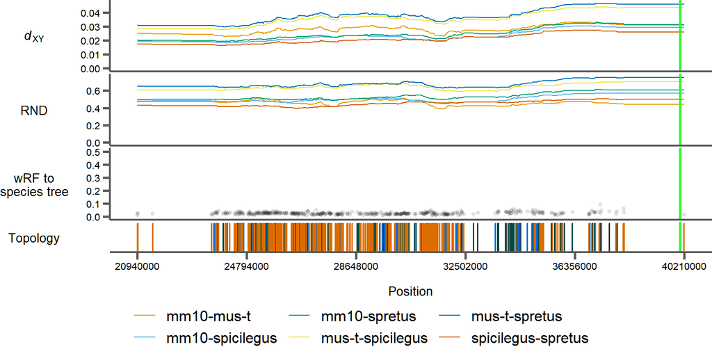

```r
sites_by_windows = sites_by_windows %>%
  mutate(roll.dxy.pair = rollapply(dxy.pair, width=100, FUN=function(x) mean(x, na.rm=TRUE), partial=T, fill=NA, align="left")) %>%
  mutate(roll.rnd = rollapply(rnd, width=100, FUN=function(x) mean(x, na.rm=TRUE), partial=T, fill=NA, align="left"))

#####

cur_chromoplot = genChromoPlot("chr17", "Inversion 4", features=inversions, cur_feature=inversions[4,], num_flank_windows=50, multi_row=F)

#####

cur_rfplot = genRFPlot(dists, "wrf.st", "chr17", "Inversion 4", "wRF to\nspecies tree", ymax=0.5, features=inversions, cur_feature=inversions[4,], num_flank_windows=50)

#####

cur_d_plot = genRFPlot(sites_by_windows, "roll.dxy.pair", "chr17", "Inversion 4", expression(italic("d")[XY]), type="line", groups="label", features=inversions, cur_feature=inversions[4,], num_flank_windows=50)

cur_rnd_plot = genRFPlot(sites_by_windows, "roll.rnd", "chr17", "Inversion 4", "RND", type="line", groups="label", features=inversions, cur_feature=inversions[4,], num_flank_windows=50)

p_main = plot_grid(cur_d_plot[[1]], cur_rnd_plot[[1]], cur_rfplot[[1]], cur_chromoplot, nrow=4, align="v", rel_heights=c(1,1,1,1,1,2))
p = plot_grid(p_main, cur_d_plot[[2]], nrow=2, rel_heights=c(1,0.2))
print(p)
```

# 7 Baseline comparisons to non-inversion windows

````r
doStats <- function(df, yvar, ylabel, filter_flag = FALSE){
  groupvar = "inv.overlap"

  df = df %>%
    drop_na(!!sym(yvar)) %>%
    filter(is.finite(!!sym(yvar)))

  if(filter_flag){
    df = df %>% filter(!!sym(yvar) < 1)
  }
  # Get rid of the NAs and filter values higher than 1
  #browser()
  df_anova = aov(reformulate(groupvar, yvar), data=df)
  df_anova_res = residuals(df_anova)
  df_anova_res_sample = sample(df_anova_res, 5000, replace=T)
  df_anova_shapiro = shapiro.test(df_anova_res_sample)
  # Do the ANOVA and check the distribution of the residuals

  #qqnorm(d_anova_res)
  #qqline(d_anova_res)

  cat("\n\n<details><summary>&#9654; Click to reveal ", ylabel, " stats</summary>\n")

  anova_qqplot = ggqqplot(df_anova_res) +
    ggtitle(paste(pair, " - ", ylabel, " - QQ Plot of Residuals")) +
    xlab("Theoretical Quantiles") +
    ylab("Sample Quantiles") +
    annotate("text", x=2, y=2, label=paste("Shapiro p-value =", round(df_anova_shapiro$p.value, digits = 5)))
  print(anova_qqplot)
  # Plot a qqplot to visualize

  cat(paste("```Shapiro p-value (null: ANOVA residuals are normally distributed): ", round(df_anova_shapiro$p.value, digits = 5), "```\n"))

  df_levene = leveneTest(df[[yvar]], df[[groupvar]], center=mean)
  cat(paste("```Levene p-value (null: variances among the groups are the same): ", round(df_levene[1, "Pr(>F)"]), "```\n"))
  # Check if for homoscedasticity between pairs of distributions

  cat("```Since data are not normal or homosecdastic, we don't do ANOVA.```\n")

  ## Check if data are normal and have homoscedasticity for an ANOVA (they aren't)
  ##########

  df_kw = kruskal.test(reformulate(groupvar, yvar), data=df)
  cat(paste("```Kruskal p-value (null: groups are the same): ", round(df_kw$p.value, digits = 5), "```\n"))
  # Perform the Kruskal test as a non-parametric alternative to ANOVA
  # to determine if groups are the same (null)

  cat("\n</details>")

  # d_dunn = dunnTest(d.out.jc ~ inv.overlap, data=kruskal_data, method="bonferroni")
  # d_dunn_df = as.data.frame(d_dunn$res)
  # # Dunn test for pairwise differences

  ##########

  inv_groups = unique(df[[groupvar]])
  # Get the list of inversion groups

  pairwise_results = data.frame()
  # Initialize a data frame to store the results

  for (i in 1:(length(inv_groups) - 1)) {
    for (j in (i + 1):length(inv_groups)) {
      # Loop over each pair of groups

      if(inv_groups[i] == "Non-inversion" || inv_groups[j] == "Non-inversion") {
        group1_data <- df[[yvar]][df[[groupvar]] == inv_groups[i]]
        group2_data <- df[[yvar]][df[[groupvar]] == inv_groups[j]]
        # Subset the data for the two groups

        wilcox_result <- wilcox.test(group1_data, group2_data, conf.int = TRUE)
        # Perform the Wilcox test

        pairwise_results = rbind(pairwise_results, data.frame(
          Group1 = inv_groups[i],
          Group2 = inv_groups[j],
          MedianDifference = wilcox_result$estimate,
          ConfLow = wilcox_result$conf.int[1],
          ConfHigh = wilcox_result$conf.int[2],
          wilcox.p = wilcox_result$p.value
        ))
        # Store the results
      }
    }
  }

  #print(pairwise_results)
  # Print the results
  #browser()
  pairwise_results$sig = "N.S."
  pairwise_results$sig <- ifelse(pairwise_results$wilcox.p <= 0.05, "*", pairwise_results$sig)
  pairwise_results$sig <- ifelse(pairwise_results$wilcox.p <= 0.01, "**", pairwise_results$sig)
  pairwise_results$sig <- ifelse(pairwise_results$wilcox.p <= 0.001, "***", pairwise_results$sig)
  # Add a significance label column

  pairwise_results$GroupComparison = with(pairwise_results, paste(Group1, Group2, sep = " - "))
  pairwise_results$GroupComparison = with(pairwise_results, reorder(GroupComparison, GroupComparison))
  # Reorder the results alphabetically

  #pairwise_results$GroupComparison = with(pairwise_results, reorder(interaction(Group1, Group2), MedianDifference))
  # Reorder the results by the estimator

  # Plot the median differences with confidence intervals, colored by significance level
  pairwise_p = ggplot(pairwise_results, aes(x=GroupComparison, y=MedianDifference, color=sig)) +
    geom_point() +
    geom_errorbar(aes(ymin=ConfLow, ymax=ConfHigh), width=0.2) +
    geom_hline(yintercept=0, size=1, linetype=2) +
    scale_color_manual(values=sig_cols, limits=names(sig_cols), drop=FALSE) +
    # ggtitle(paste(pair, "- shifts in ", ylabel)) +
    #xlab("Group Comparison") +
    ylab(paste("Estimated Shift in ", ylabel)) +
    bartheme() +
    theme(panel.grid.major.x=element_line(color="#d3d3d3", size=0.5, linetype=1),
          panel.grid.major.y=element_line(color="#d3d3d3", size=0.5, linetype=1),
          # plot.title = element_text(size=14, margin=margin(b=20)),
          axis.text.x = element_text(angle=25, hjust=1, size=8),
          axis.title.x = element_text(size = 10),
          axis.text.y = element_text(size=8),
          axis.title.y = element_text(size = 10),
          plot.margin = margin(0, 0.1, 0, 0, "cm"),
          legend.position="bottom"
          )
          #axis.title.y=element_text(size=12),
          #plot.margin=margin(0.5,0.5,0,0.5, unit="cm"))
    #coord_flip()

  return(pairwise_p)
}
````

```r
pairs = unique(sites_by_windows$label)
x_comps = list(c("inv01", "Non-inversion"), c("inv02", "Non-inversion"), c("inv03", "Non-inversion"), c("inv04", "Non-inversion"))
sig_comp_lvls = c("Non-inversion-inv01", "Non-inversion-inv02", "Non-inversion-inv03", "Non-inversion-inv04")

sig_cols = c("N.S."="#333333",
             "*"=corecol(pal="wilke", numcol=1, offset=4),
             "**"=corecol(pal="wilke", numcol=1, offset=2),
             "***"=corecol(pal="wilke", numcol=1, offset=6))

summary_data = data.frame()

for(pair in pairs){

  cat(paste0("## ", pair, "\n"))

  cur_data = sites_by_windows %>%
    filter(label == pair) %>%
    mutate(inv.overlap = replace_na(inv.overlap, "Non-inversion"))

  max_y = cur_data %>%
    summarise(max = max(dxy.pair, na.rm = TRUE)) %>%
    pull(max)

  d_plot = cur_data %>%
    ggplot(aes(x=inv.overlap, y=dxy.pair)) +
    geom_quasirandom(size=2, width=0.25, alpha=0.25) +
    geom_signif(comparisons=x_comps, map_signif_level=TRUE, textsize=4, size=1, step_increase=0.12, margin_top=0.1) +
    #geom_point() +
    geom_boxplot(outlier.shape=NA) +
    coord_cartesian(ylim = c(NA, max_y * 1.6)) +
    xlab("") +
    ylab(expression(italic("d"))) +
    bartheme() +
    theme(axis.text.x = element_text(angle=25, hjust=1),
          plot.margin = margin(0, 0.1, 0, 0, "cm"))
  #print(d_plot)

  max_y = max(cur_data$rnd, na.rm = TRUE)

  rnd_plot = cur_data %>%
    ggplot(aes(x=inv.overlap, y=rnd)) +
    geom_quasirandom(size=2, width=0.25, alpha=0.25) +
    geom_signif(comparisons=x_comps, map_signif_level=TRUE, textsize=4, size=1, step_increase=0.12, margin_top=0.1) +
    #geom_point() +
    geom_boxplot(outlier.shape=NA) +
    coord_cartesian(ylim = c(NA, max_y * 1.6)) +
    xlab("") +
    ylab("RND") +
    bartheme() +
    theme(axis.text.x = element_text(angle=25, hjust=1),
          plot.margin = margin(0, 0.1, 0, 0, "cm"))
  #print(rnd_plot)

  title = ggdraw() + draw_label(pair)

  ## Plot distributions of d and RND for each inversion and non-inversion windows
  ##########

  pairwise_d_p = doStats(cur_data, "dxy.pair", "d", filter_flag=TRUE)
  pairwise_rnd_p = doStats(cur_data, "rnd", "RND")

  leg = get_legend(pairwise_d_p)
  pairwise_d_p = pairwise_d_p + theme(legend.position="none")
  pairwise_rnd_p = pairwise_rnd_p + theme(legend.position="none")

  ptop = plot_grid(d_plot, rnd_plot, nrow=1, ncol=2)
  pbtm = plot_grid(pairwise_d_p, pairwise_rnd_p, nrow=1, ncol=2)
  pmain = plot_grid(ptop, pbtm, nrow=2)
  p = plot_grid(title, pmain, leg, nrow=3, rel_heights=c(0.1, 1, 0.1))

  print(p)

  cur_data_summary = cur_data %>% summarize(mean.dxy=mean(dxy.pair, na.rm=T),
                                            median.dxy=median(dxy.pair, na.rm=T),
                                            mean.rnd=mean(rnd, na.rm=T),
                                            median.rnd=median(rnd, na.rm=T))

  summary_data = rbind(summary_data, cur_data_summary)
  cat("<br/>")
  print(
    cur_data %>% group_by(inv.overlap) %>%
    summarize(mean.dxy=mean(dxy.pair, na.rm=T),
              median.dxy=median(dxy.pair, na.rm=T),
              mean.rnd=mean(rnd, na.rm=T),
              median.rnd=median(rnd, na.rm=T)) %>%
    kable() %>%
    kable_styling(bootstrap_options=c("striped", "condended", "responsive"), full_width=F, position="center", fixed_thead=T)
  )

  cat("\n")
  cat("\n\n---\n\n")
}
```

## 7.1 mm10-mus-t

**▶ Click to reveal d stats**

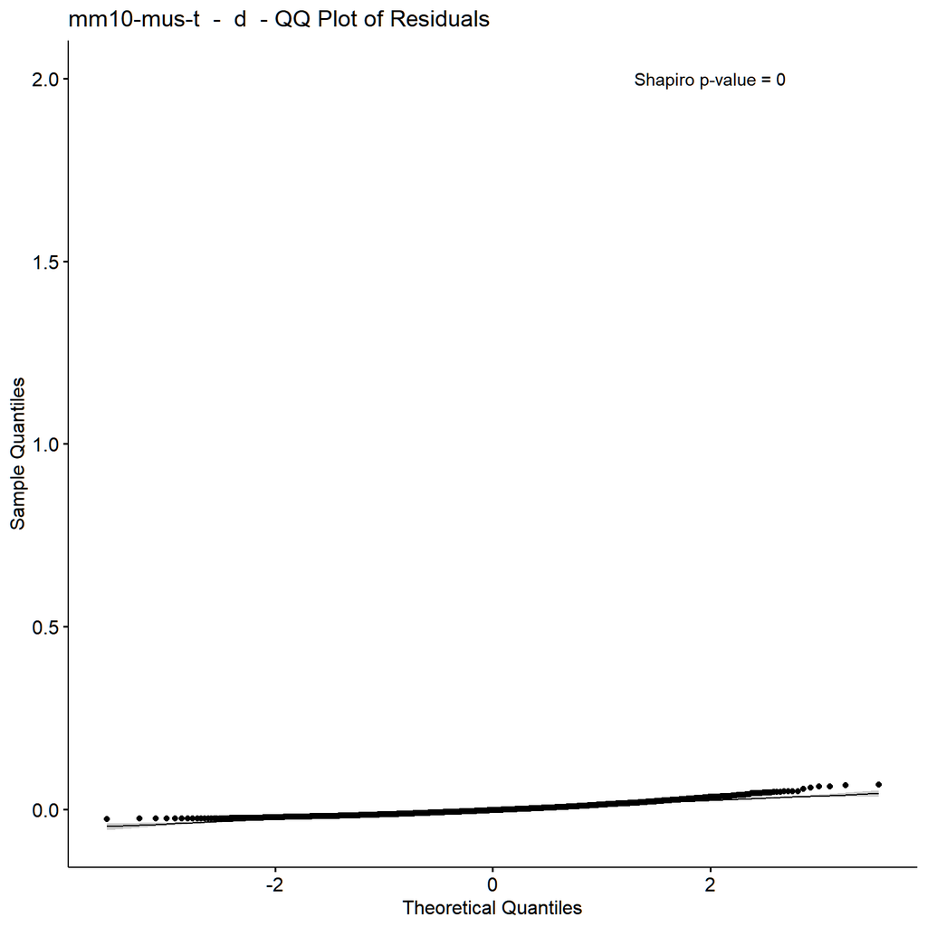

`Shapiro p-value (null: ANOVA residuals are normally distributed): 0` `Levene p-value (null: variances among the groups are the same): 0` `Since data are not normal or homosecdastic, we don't do ANOVA.` `Kruskal p-value (null: groups are the same): 0.00031`

**▶ Click to reveal RND stats**

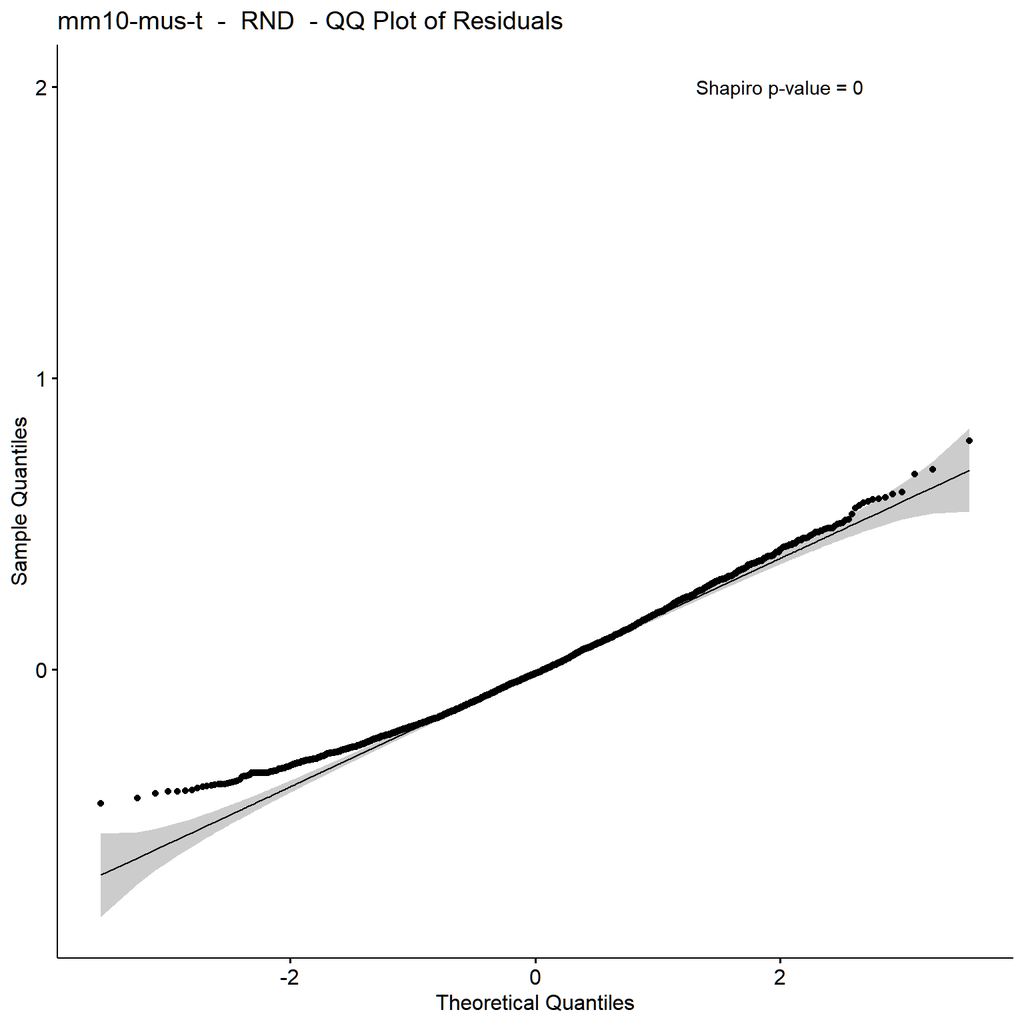

`Shapiro p-value (null: ANOVA residuals are normally distributed): 0` `Levene p-value (null: variances among the groups are the same): 0` `Since data are not normal or homosecdastic, we don't do ANOVA.` `Kruskal p-value (null: groups are the same): 0`

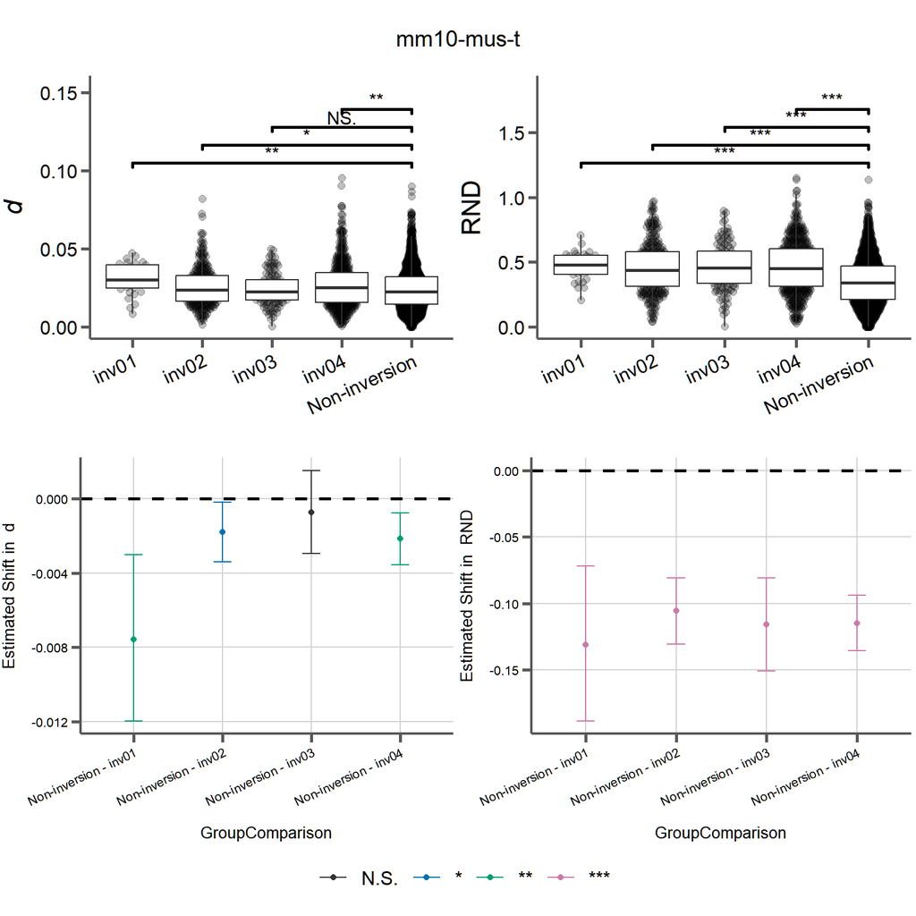

| inv.overlap | mean.dxy | median.dxy | mean.rnd | median.rnd |
| --- | --- | --- | --- | --- |
| Non-inversion | 0.0244763 | 0.0225464 | 0.3532473 | 0.3390276 |
| inv01 | 0.0306293 | 0.0301952 | 0.4714373 | 0.4797628 |
| inv02 | 0.0260291 | 0.0236243 | 0.4589908 | 0.4375804 |
| inv03 | 0.0243337 | 0.0224519 | 0.4640020 | 0.4551193 |
| inv04 | 0.0270987 | 0.0252776 | 0.4656049 | 0.4534161 |

## 7.2 mm10-spicilegus

**▶ Click to reveal d stats**

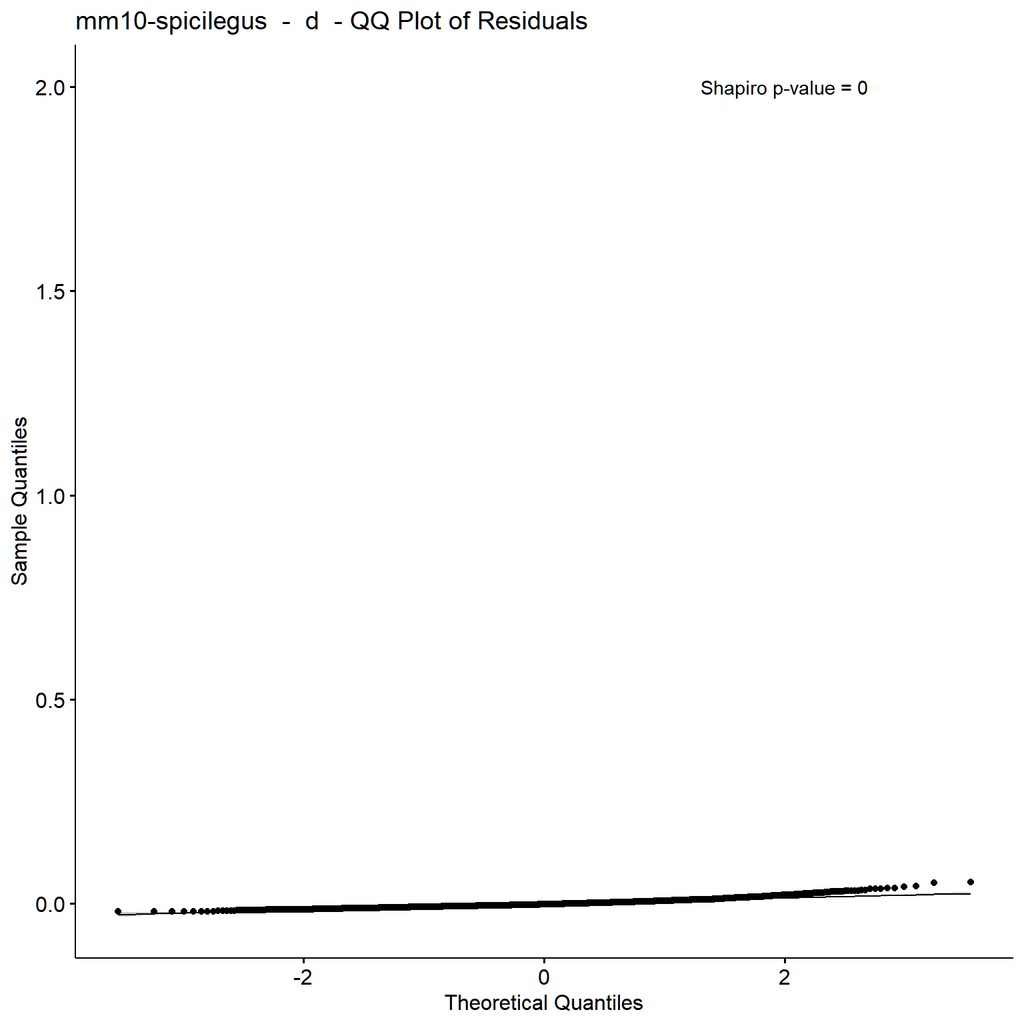

`Shapiro p-value (null: ANOVA residuals are normally distributed): 0` `Levene p-value (null: variances among the groups are the same): 0` `Since data are not normal or homosecdastic, we don't do ANOVA.` `Kruskal p-value (null: groups are the same): 0`

**▶ Click to reveal RND stats**

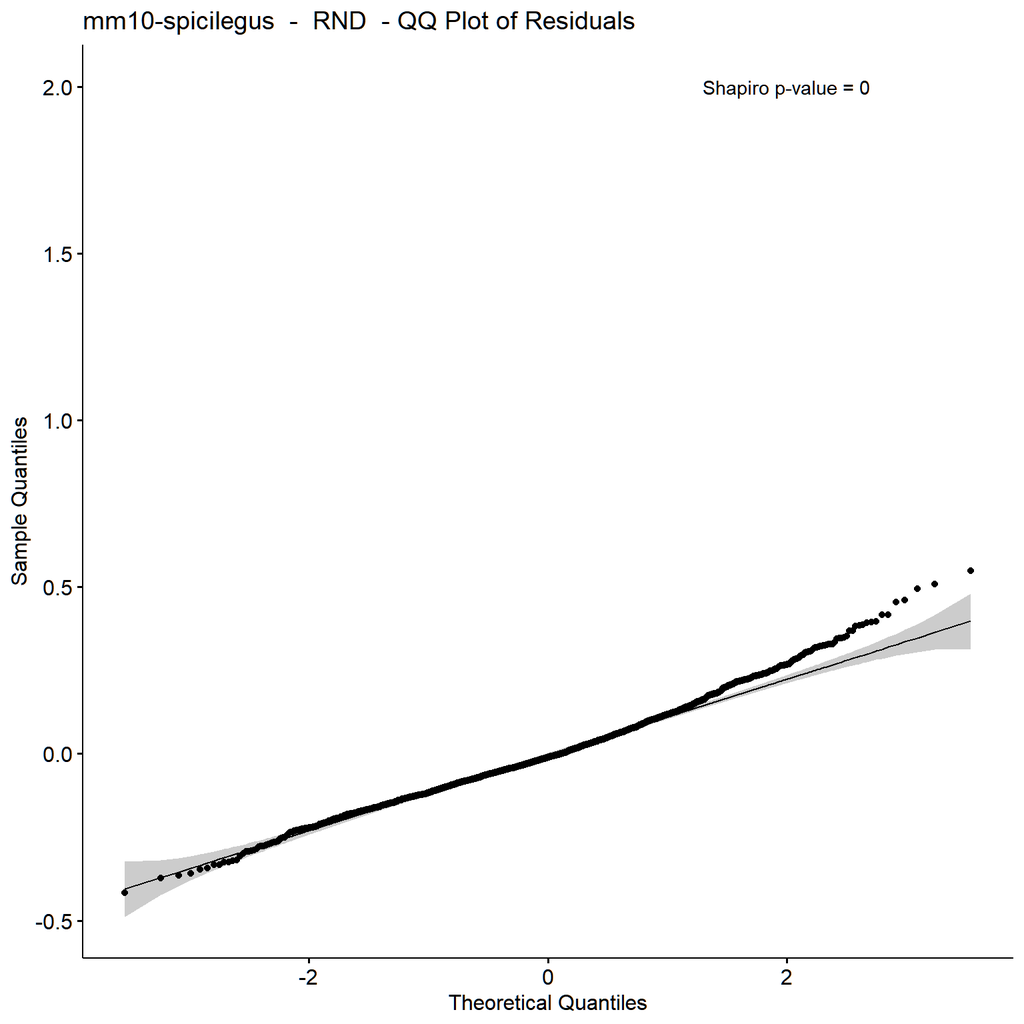

`Shapiro p-value (null: ANOVA residuals are normally distributed): 0` `Levene p-value (null: variances among the groups are the same): 0` `Since data are not normal or homosecdastic, we don't do ANOVA.` `Kruskal p-value (null: groups are the same): 0`

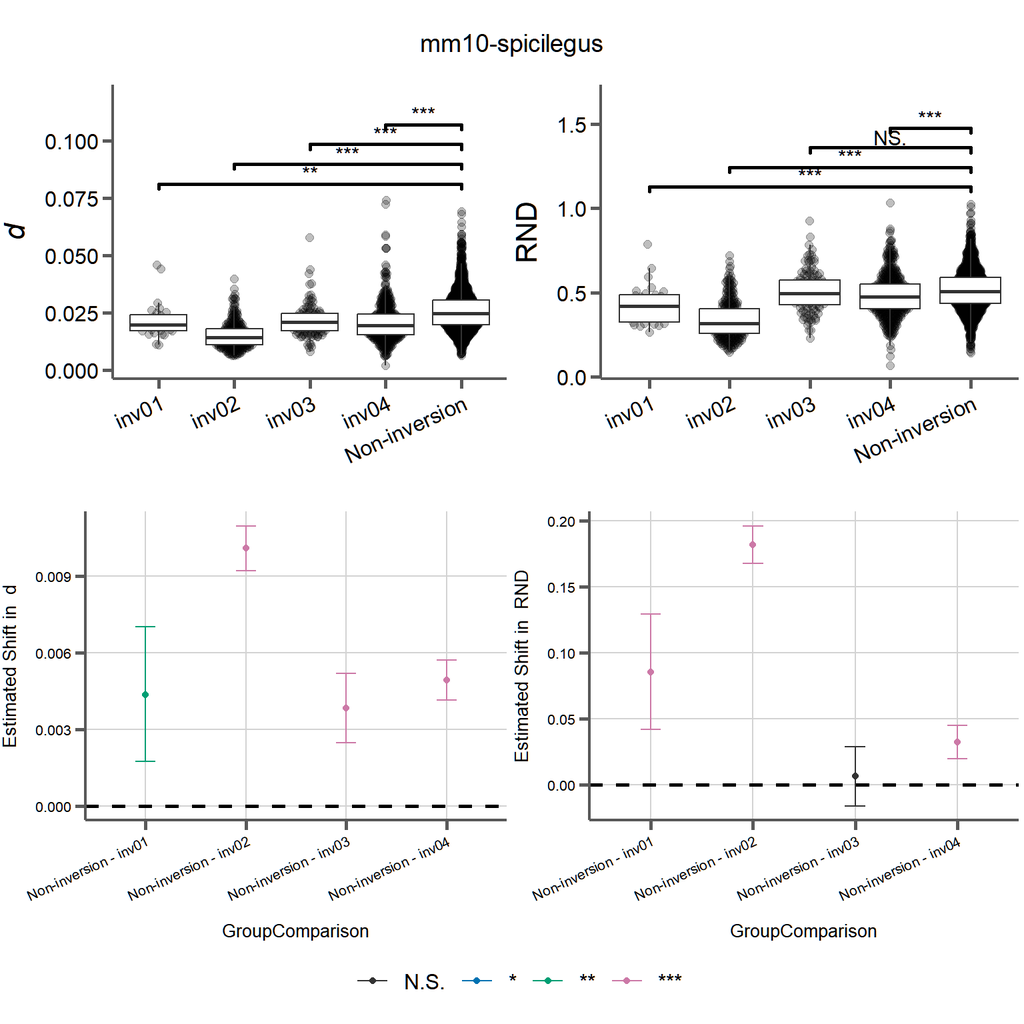

| inv.overlap | mean.dxy | median.dxy | mean.rnd | median.rnd |
| --- | --- | --- | --- | --- |
| Non-inversion | 0.0259348 | 0.0246648 | 0.5152404 | 0.5073650 |
| inv01 | 0.0216257 | 0.0198571 | 0.4337441 | 0.4203735 |
| inv02 | 0.0153226 | 0.0143374 | 0.3388754 | 0.3159341 |
| inv03 | 0.0217530 | 0.0210809 | 0.5102784 | 0.4965586 |
| inv04 | 0.0210894 | 0.0196212 | 0.4845502 | 0.4745763 |

## 7.3 mm10-spretus

**▶ Click to reveal d stats**

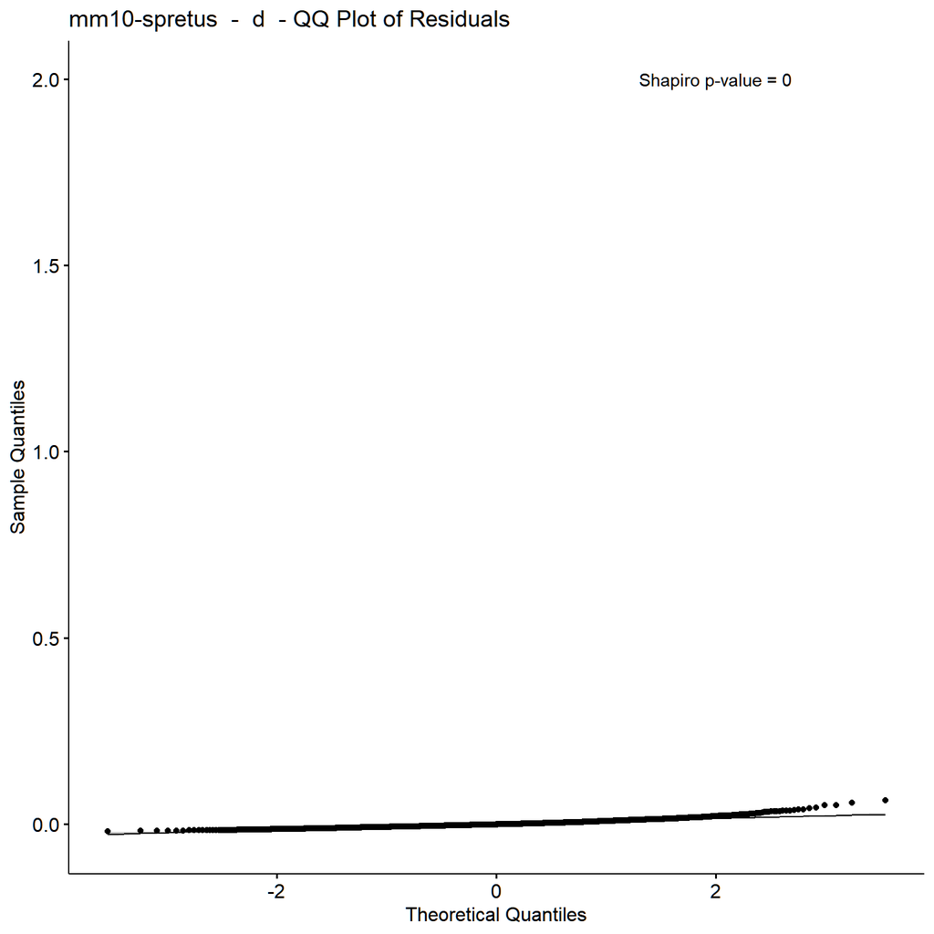

`Shapiro p-value (null: ANOVA residuals are normally distributed): 0` `Levene p-value (null: variances among the groups are the same): 0` `Since data are not normal or homosecdastic, we don't do ANOVA.` `Kruskal p-value (null: groups are the same): 0`

**▶ Click to reveal RND stats**

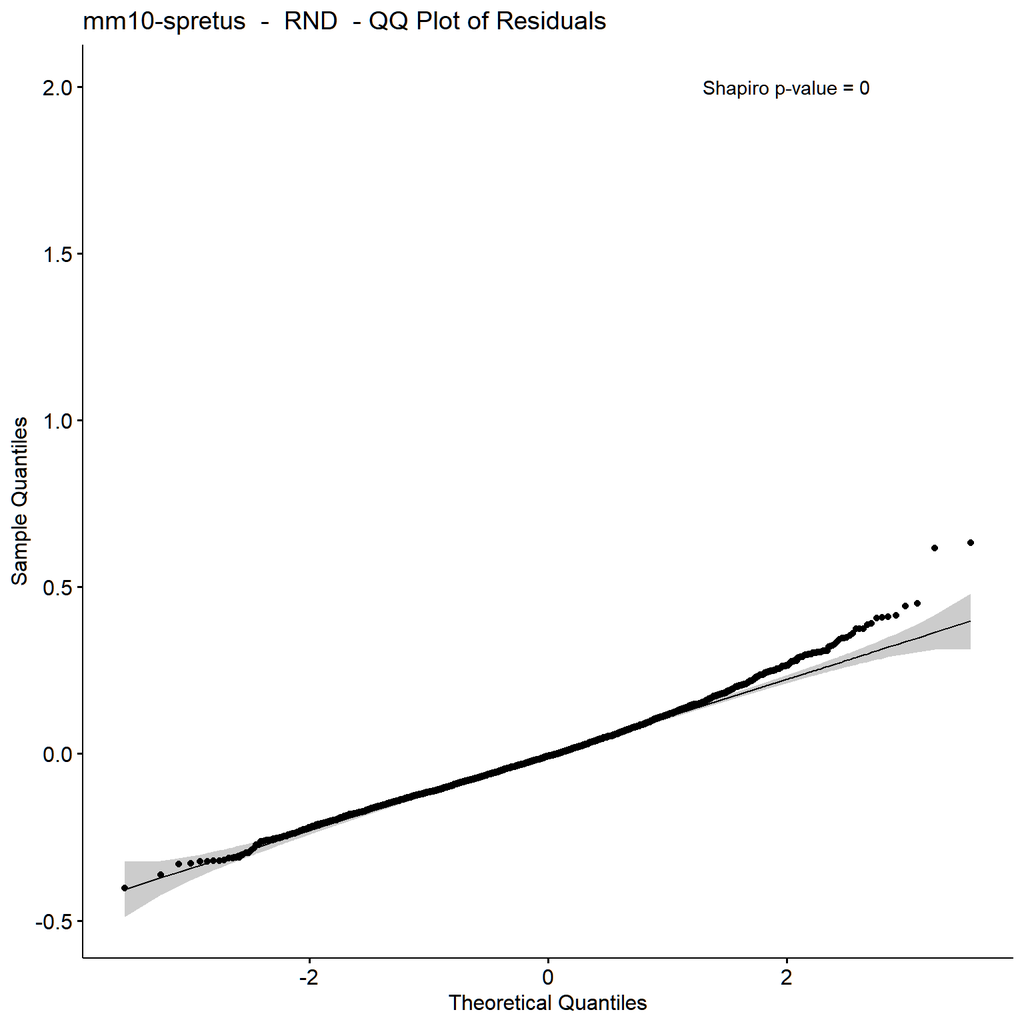

`Shapiro p-value (null: ANOVA residuals are normally distributed): 0` `Levene p-value (null: variances among the groups are the same): 0` `Since data are not normal or homosecdastic, we don't do ANOVA.` `Kruskal p-value (null: groups are the same): 0`

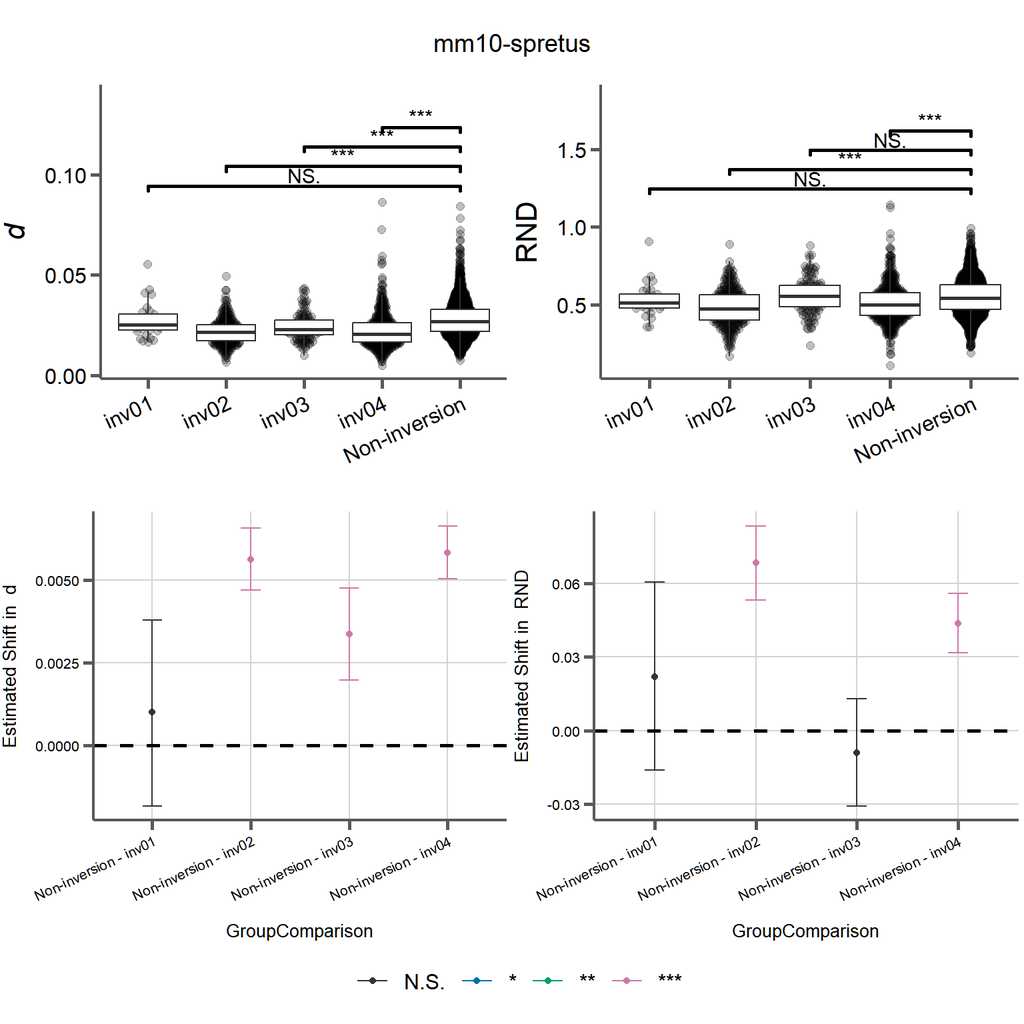

| inv.overlap | mean.dxy | median.dxy | mean.rnd | median.rnd |
| --- | --- | --- | --- | --- |
| Non-inversion | 0.0280312 | 0.0269310 | 0.5510966 | 0.5442597 |
| inv01 | 0.0272934 | 0.0253408 | 0.5314874 | 0.5122242 |
| inv02 | 0.0218767 | 0.0214493 | 0.4818935 | 0.4734300 |
| inv03 | 0.0242926 | 0.0228784 | 0.5584346 | 0.5535714 |
| inv04 | 0.0224011 | 0.0205453 | 0.5106586 | 0.4989154 |

## 7.4 mus-t-spicilegus

**▶ Click to reveal d stats**

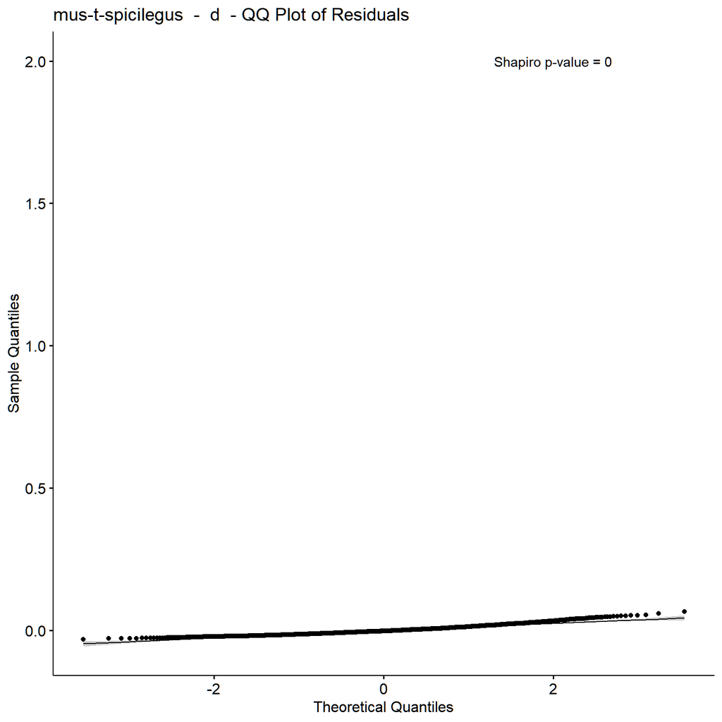

`Shapiro p-value (null: ANOVA residuals are normally distributed): 0` `Levene p-value (null: variances among the groups are the same): 0` `Since data are not normal or homosecdastic, we don't do ANOVA.` `Kruskal p-value (null: groups are the same): 0`

**▶ Click to reveal RND stats**

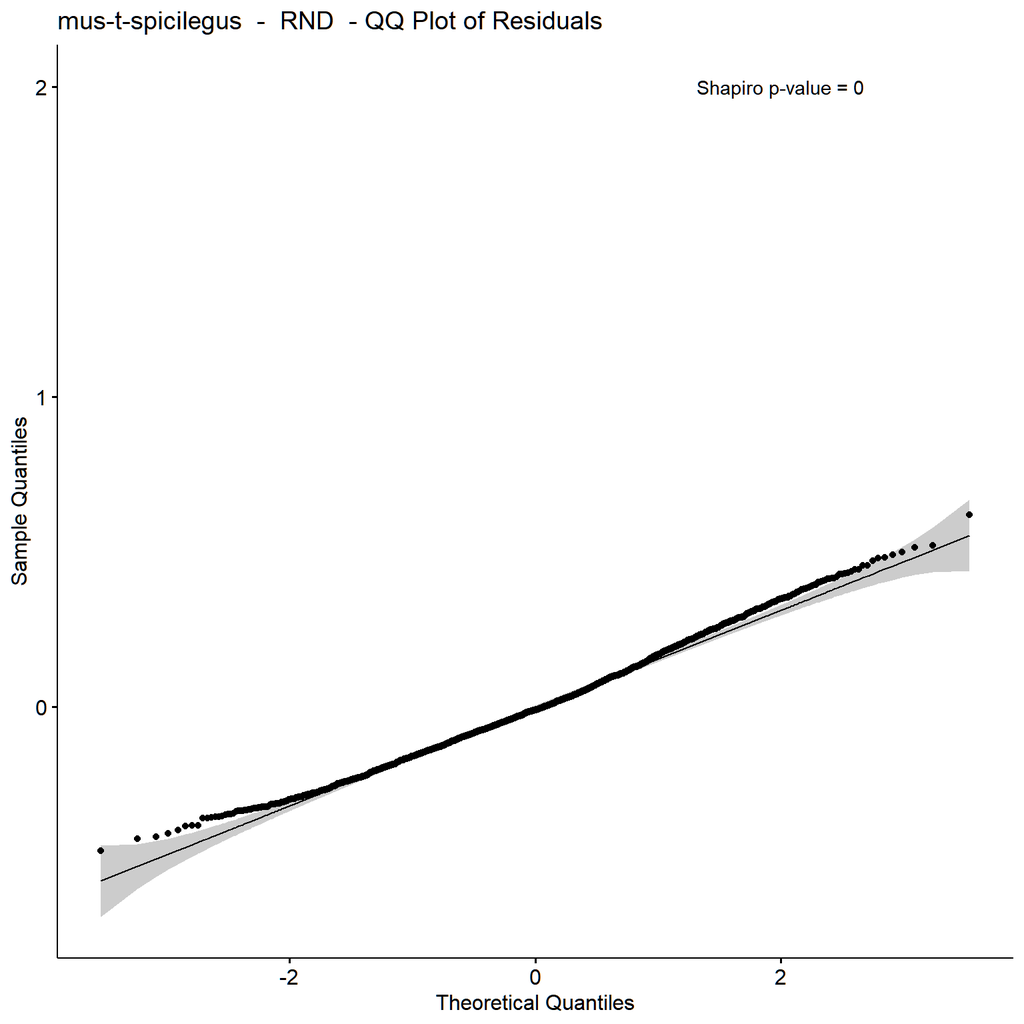

`Shapiro p-value (null: ANOVA residuals are normally distributed): 0` `Levene p-value (null: variances among the groups are the same): 0` `Since data are not normal or homosecdastic, we don't do ANOVA.` `Kruskal p-value (null: groups are the same): 0`

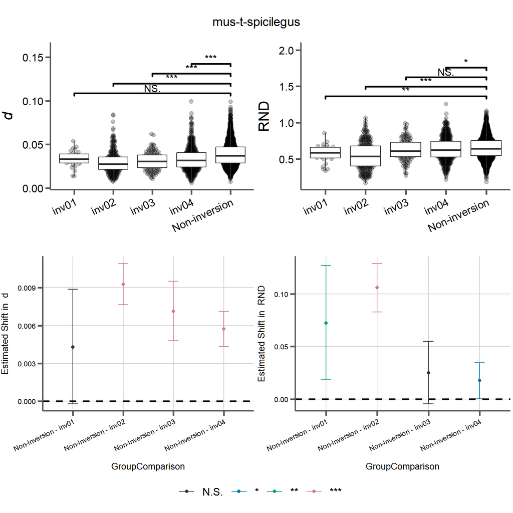

| inv.overlap | mean.dxy | median.dxy | mean.rnd | median.rnd |
| --- | --- | --- | --- | --- |
| Non-inversion | 0.0391874 | 0.0371069 | 0.6523292 | 0.6430769 |
| inv01 | 0.0335471 | 0.0333606 | 0.5720575 | 0.5871476 |
| inv02 | 0.0298051 | 0.0277380 | 0.5488684 | 0.5365508 |
| inv03 | 0.0310760 | 0.0307983 | 0.6251372 | 0.6084461 |
| inv04 | 0.0335029 | 0.0317583 | 0.6363618 | 0.6244730 |

## 7.5 mus-t-spretus

**▶ Click to reveal d stats**

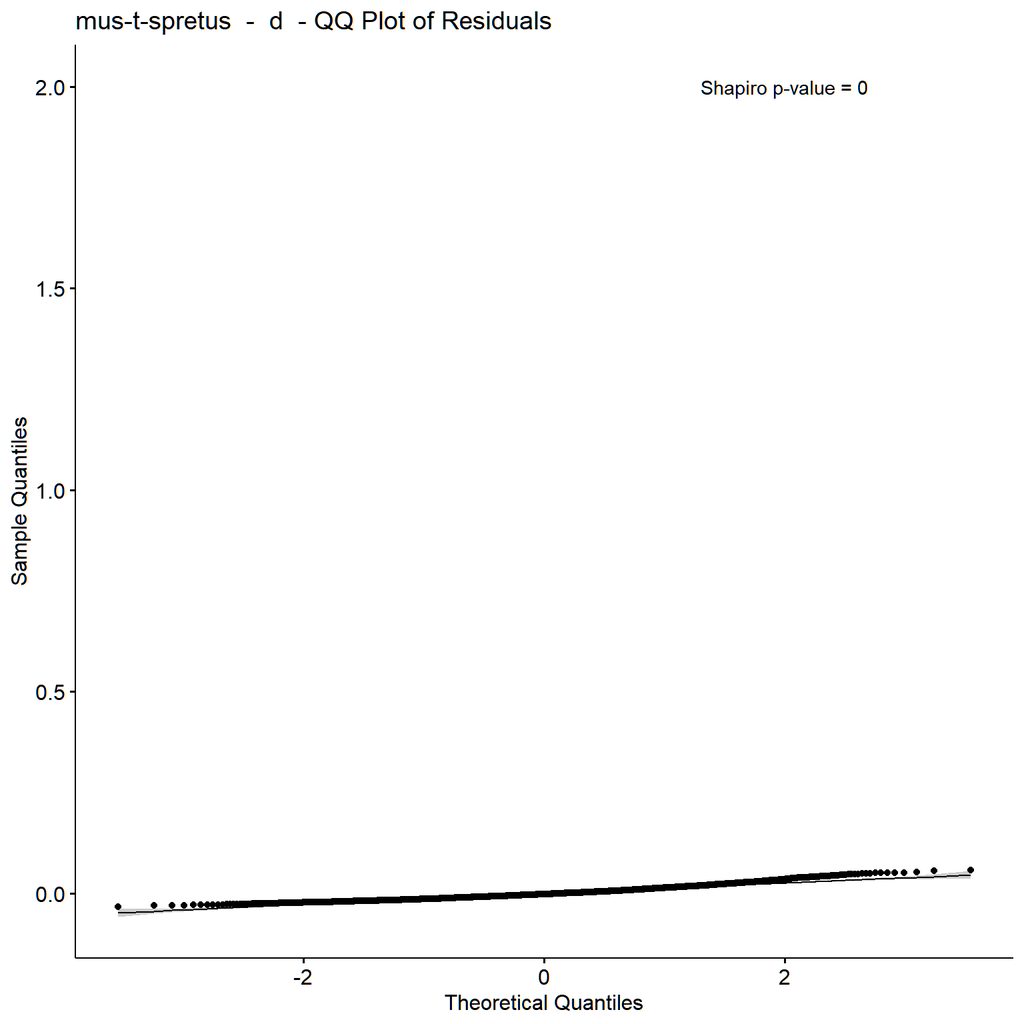

`Shapiro p-value (null: ANOVA residuals are normally distributed): 0` `Levene p-value (null: variances among the groups are the same): 0` `Since data are not normal or homosecdastic, we don't do ANOVA.` `Kruskal p-value (null: groups are the same): 0`

**▶ Click to reveal RND stats**

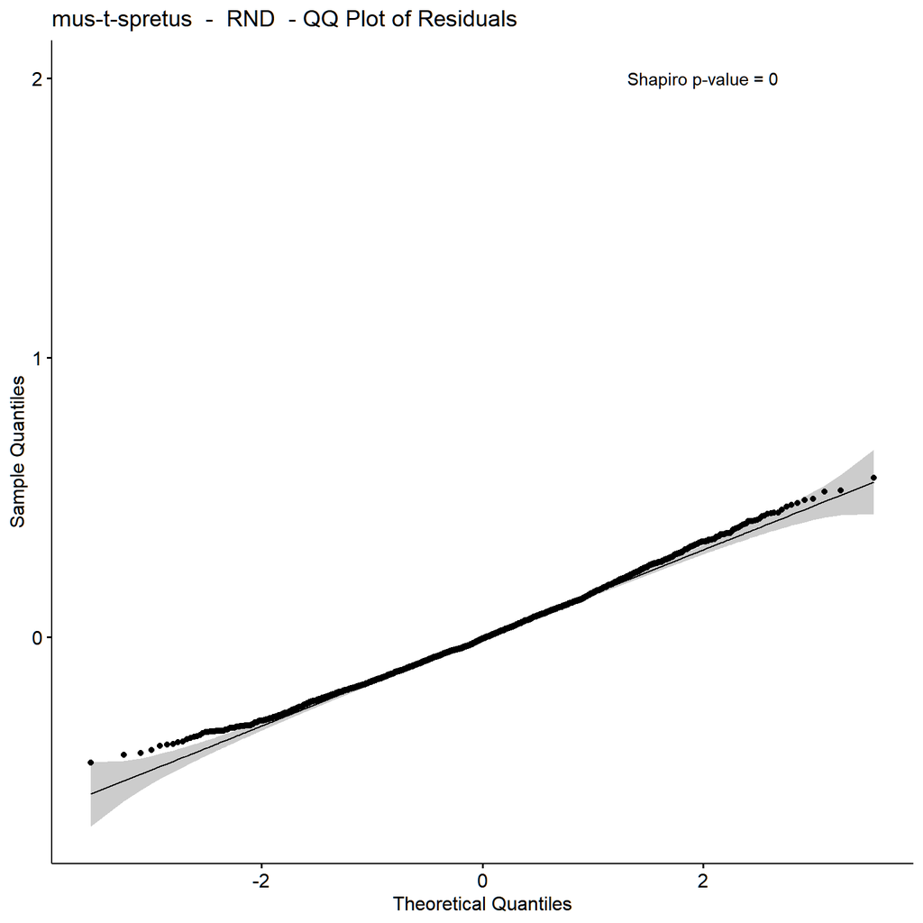

`Shapiro p-value (null: ANOVA residuals are normally distributed): 0` `Levene p-value (null: variances among the groups are the same): 0` `Since data are not normal or homosecdastic, we don't do ANOVA.` `Kruskal p-value (null: groups are the same): 0.00011`

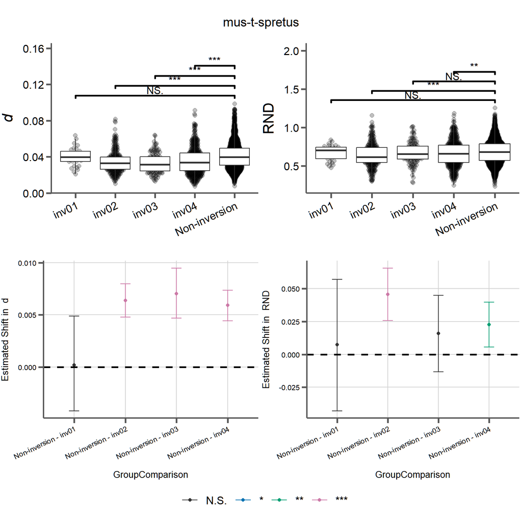

| inv.overlap | mean.dxy | median.dxy | mean.rnd | median.rnd |
| --- | --- | --- | --- | --- |
| Non-inversion | 0.0413147 | 0.0396805 | 0.6836748 | 0.6781915 |
| inv01 | 0.0400134 | 0.0396758 | 0.6701402 | 0.7011913 |
| inv02 | 0.0345327 | 0.0329382 | 0.6395069 | 0.6148867 |
| inv03 | 0.0334294 | 0.0314984 | 0.6659806 | 0.6527099 |
| inv04 | 0.0354835 | 0.0336700 | 0.6612965 | 0.6593407 |